# KimbePredsBiomass

Ben Cresswell

24 July, 2021

# Rmd created: 2.7.2021 BJC

# Last edit: 21.7.2021 BJC on Argo

## Introduction

This document analyses predator fish biomass from the Kimbe Bay video survey data set.

## Packages and housekeeping

```r
rm(list=ls())
#graphics.off()

library(gridExtra) #for plotting
library(gt)
library(lme4)      #basic model builder
library(car)       #for regression diagnostics
library(multcomp)  #for lm work
library(broom)     #for tidy output
library(ggfortify) #for model diagnostics
library(DHARMa)    #for residual diagnostics
library(performance)
library(glmmTMB)   #for wider selection of error families
library(sjPlot)    #for outputs
library(effects)   #for partial effects plots
library(ggeffects) #for partial effects plots
library(emmeans)   #for estimating marginal means
library(modelr)    #for auxillary modelling functions
library(artyfarty) #for plotting
library(MuMIn)     #for pseudo R2
library(tidyverse) #for data wrangling
```

## Rmd setup, directory selection

```r
knitr::opts_chunk$set(root.dir = "code/PredBiomass", echo = TRUE)
```

## Data import and wrangling

```r
source("pred_biom_diw.R", local = knitr::knit_global())
```

# Variables:

Modeling predator biomass (response variable) against reef type (fixed effect predictor variable), with site as a random effect:

1. Biomass (response variable - raw data in grams but diw converts to kg for rest of analysis)
2. Reef type (predictor variable - fixed effect): Factor with 3 ‘levels’.
3. Site (nested random effect): 4, nested within reef type, 12 total.
4. Total biomass of fish (scaling variable): Need to scale the model to account for total fish biomass?? –> Check if this makes a difference

# Basic data exploration

merpredsum has the transect_biomass column in it. Can also run using: source(“pred_biom_eda.R”, local = knitr::knit_global())

```r
# Load data (if not running above chunks)
load(file = "../../data/merpredsum_kg.RData")

# Glimpse
glimpse(merpredsum_kg)
```

```
## Rows: 120
## Columns: 9
## $ TID                      <fct> BRAD_T1_0319, BRAD_T1_1018, BRAD_T2_0319, BRA…
## $ SiteSurv                 <fct> BRAD 0319, BRAD 1018, BRAD 0319, BRAD 1018, B…
## $ SurvCode                 <fct> 0319, 1018, 0319, 1018, 0319, 1018, 0319, 101…
## $ Site                     <fct> Bradford, Bradford, Bradford, Bradford, Bradf…
## $ SiteCode                 <fct> BRAD, BRAD, BRAD, BRAD, BRAD, BRAD, BRAD, BRA…
## $ Transect                 <fct> T1, T1, T2, T2, T3, T3, T4, T4, T5, T5, T1, T…
## $ Reeftype                 <fct> Pinnacle, Pinnacle, Pinnacle, Pinnacle, Pinna…
## $ Transect_biomass_kg      <dbl> 1.690239e+02, 1.699737e+02, 9.680305e+01, 1.5…
## $ Transect_Fish_Biomass_kg <dbl> 231.305686, 253.471647, 154.633980, 12.621020…
```

```r
# Fig. 1: Histogram of all data
hist1 <- ggplot(merpredsum_kg, aes(x=Transect_biomass_kg)) +
  geom_histogram(color="black", fill="grey")

# Fig. 2: Histogram of data on log scale
hist2 <- ggplot(merpredsum_kg, aes(x=log(Transect_biomass_kg))) +
  geom_histogram(color="black", fill="grey")

# Table 1 and Fig. 3: Compare sites:
(predreeftypestats <- merpredsum_kg %>%
  group_by(Reeftype) %>%
  summarise_each(funs(mean,sd,se=sd(.)/sqrt(n())), Transect_biomass_kg))
```

| Reeftype | mean | sd | se |
| --- | --- | --- | --- |
| Pinnacle | 121.6172308 | 485.995678 | 76.8426638 |
| Offshore | 2.7451291 | 3.591401 | 0.5678503 |
| Nearshore | 0.5569959 | 1.404210 | 0.2220250 |

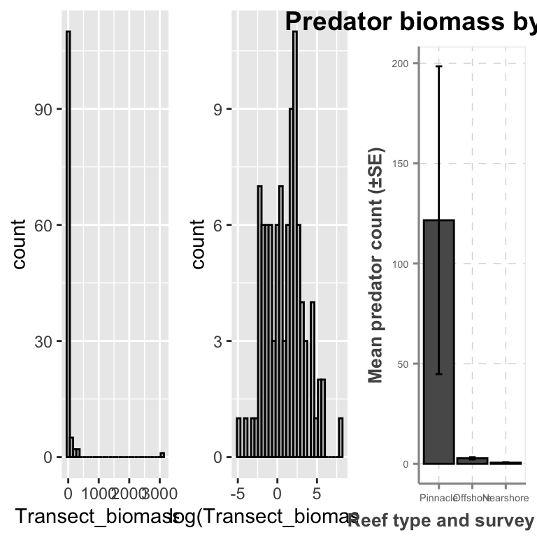

```r
# Fig 3
rtbar <- ggplot(predreeftypestats, aes(x=Reeftype, y=mean))+
  geom_bar(stat="identity", position="dodge", color="black")+
  scale_y_continuous("Mean predator count (±SE)")+
  scale_x_discrete("Reef type and survey period")+
  labs(title="Predator biomass by reef type")+
  scale_fill_viridis_d()+
  theme_scientific()+
  geom_errorbar(aes(ymin=mean-se, ymax=mean+se), width=.2, position=position_dodge(.9))+
  theme(legend.key.size = unit(0.4, "cm"))+
  theme(plot.title = element_text(size = 14, face = "bold"),
        legend.title=element_text(size=9),
        legend.text=element_text(size=8),
        axis.title.y = element_text(size=10, face="bold"),
        axis.title.x = element_text(size=10, face="bold"),
        axis.text = element_text(size=6))

# And plot
grid.arrange(hist1, hist2, rtbar, nrow=1)
```

- Lots of zeros so perhaps will need a ZI term in the model. - Log hist looks normal so prob will need a distribution on the log scale - Not count data so not really expecting Poisson or neg binom distributions to work best. - As per abundance, predator biomass highest on pinnacles - Exaggerated by large schools of large pelagic/semi-pelagic fishes (in particular S. qenie)

# Fit models

Will start with basic GLMM with site as random factor. Definitely not going to be Gaussian, Gamma (zeros), Beta (not 0-1). Will start with Poisson, Neg Binom, ZI and Tweedie. Will introduce offset later on to account for total fish biomass

```r
# Poisson
pred.glmmp <- glmmTMB(Transect_biomass_kg~Reeftype+(1|SiteCode), data=merpredsum_kg, family=genpois())
# Negbinom
pred.glmmnb2 <- glmmTMB(Transect_biomass_kg~Reeftype+(1|SiteCode), data=merpredsum_kg, family=nbinom2(link = "log"))
# ZI on nb
pred.glmmzi <- glmmTMB(Transect_biomass_kg~Reeftype+(1|SiteCode), data=merpredsum_kg, family=nbinom2(), ziformula=~1)
# Tweedie
pred.glmmt <- glmmTMB(Transect_biomass_kg~Reeftype+(1|SiteCode), data=merpredsum_kg, family=tweedie(link = "log"))
```

# Source code for all models trialled if required (model comparisons etc)

```r
#
```

# Model diagnostics

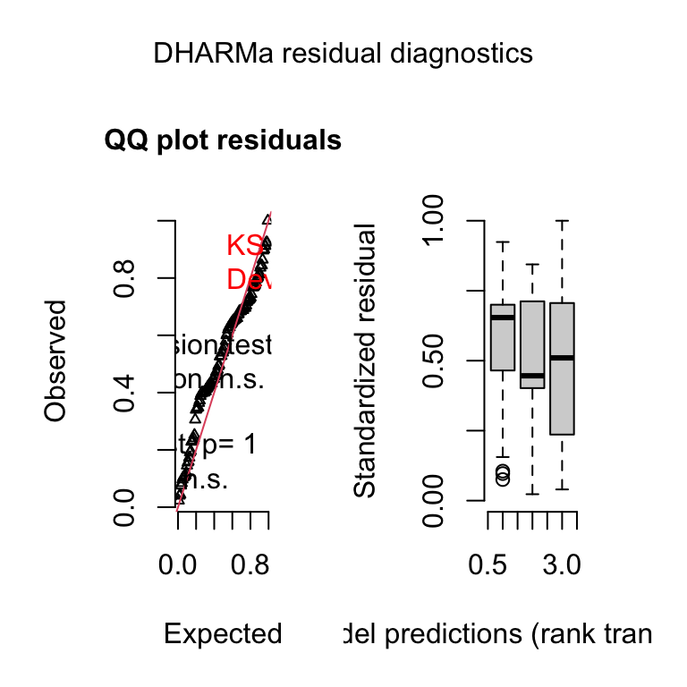

```
## Object of Class DHARMa with simulated residuals based on 250 simulations with refit = FALSE . See ?DHARMa::simulateResiduals for help.
##
## Scaled residual values: 0.912 0.9 0.844 0.104 0.912 1 0.924 0.24 0.688 0.896 0.652 0.4120755 0.696 0.924 0.864 0.66 0.768 0.796 0.4731329 0.724 ...
```

```r
simulateResiduals(pred.glmmp, plot=T) #
```

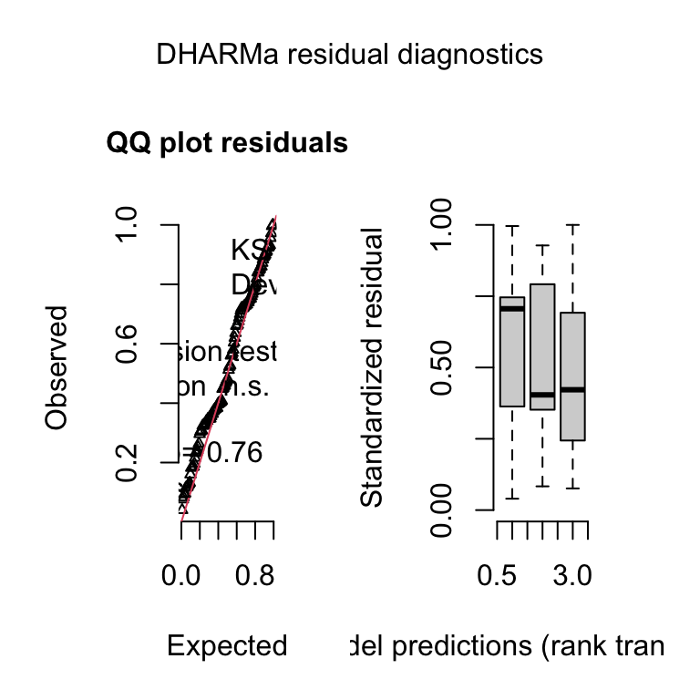

```
## Object of Class DHARMa with simulated residuals based on 250 simulations with refit = FALSE . See ?DHARMa::simulateResiduals for help.
##
## Scaled residual values: 0.892 0.924 0.82 0.124 0.932 1 0.956 0.232 0.636 0.912 0.752 0.6599917 0.792 0.996 0.972 0.728 0.84 0.884 0.1183213 0.72 ...
```

```r
simulateResiduals(pred.glmmnb2, plot=T)
```

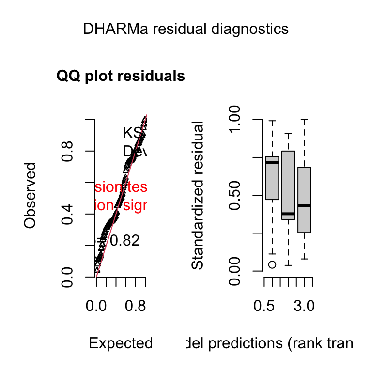

```
## Object of Class DHARMa with simulated residuals based on 250 simulations with refit = FALSE . See ?DHARMa::simulateResiduals for help.
##
## Scaled residual values: 0.896 0.896 0.772 0.128 0.972 1 0.968 0.236 0.592 0.896 0.728 0.262678 0.672 0.992 0.948 0.732 0.864 0.908 0.04198545 0.752 ...
```

```r
simulateResiduals(pred.glmmzi, plot=T)
```

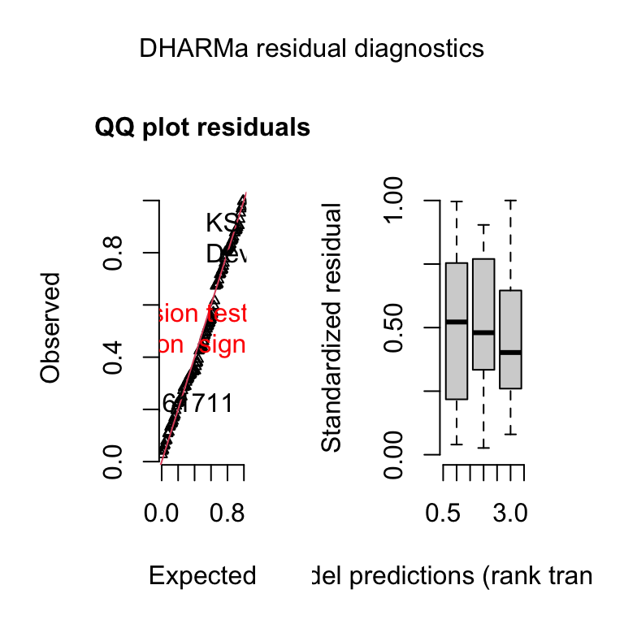

```
## Object of Class DHARMa with simulated residuals based on 250 simulations with refit = FALSE . See ?DHARMa::simulateResiduals for help.
##
## Scaled residual values: 0.896 0.876 0.776 0.136 0.952 1 0.976 0.248 0.616 0.884 0.672 0.2241527 0.748 0.996 0.968 0.82 0.888 0.928 0.2474691 0.82 ...
```

```r
simulateResiduals(pred.glmmt, plot=T)
```

- Neg binom best residual fit